## Data Wrangling Final Project-Code Part 1 of 2

## Bank Products Issues, Fraud, and the People Affected

```r
chooseCRANmirror(graphics=FALSE, ind=1)
knitr::opts_chunk$set(echo = TRUE)
library("janitor")
library("vtree")
library("tidyverse")
library("dplyr")
library("tidytext")
library("stringr")
library("rvest")
library("stopwords")
library("choroplethrMaps")
library("choroplethr")
library("plyr")
library("lubridate")
library("clean")
library("cleaner")
library("ggQC")
```

## Code will support what banks have officially been served complaints by their users and how responsive they are to such issues. In addition the work will support which institutions should improve and in what areas. As a follow up I will pull information on identity theft of personal information and how this impacts similar sets of customers.

## To compare customers with banks, we must first build profiles on which users are utilizing credit products and how it is used. From there I will look at patterns and trends.

## Section 1

## First data set is customer application dataset for credit products.

```r
customer_data <- read.csv(file = 'customer_application_data.csv')
unique_customers <- length(unique(customer_data$SK_ID_CURR))
unique_customers
```

```
## [1] 307511
```

## The customer count above supports that there is 307k unique values, so this is a large normalized data set.

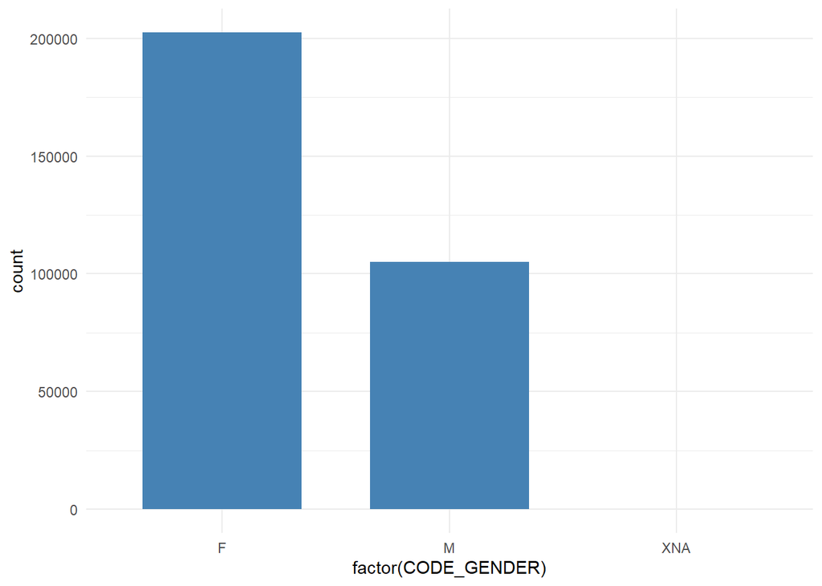

```r
customer_data_gender <- ggplot(customer_data, aes(x=factor(CODE_GENDER))) +
  geom_bar(stat="count", width=0.7, fill="steelblue") +
  theme_minimal()
customer_data_gender
```

## The above shows a graphic that has almost twice the number of female credit customers versus male customers. This graph and the below supports a profile of active users of credit in a normal banking institution.

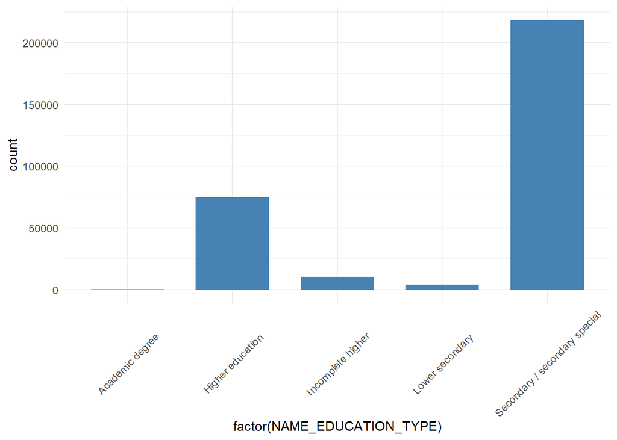

```r
customer_data_education_type <- ggplot(customer_data, aes(x=factor(NAME_EDUCATION_TYPE))) +
  geom_bar(stat="count", width=0.7, fill="steelblue") +
  theme_minimal() +
  theme(axis.text.x = element_text(angle = 45, vjust = 0.5))
customer_data_education_type
```

## The education type of a typical customer is secondary or secondary special. This makes sense as many people have some time of higher level degree or secondary education completed, especially if they have the income to take out credit products.

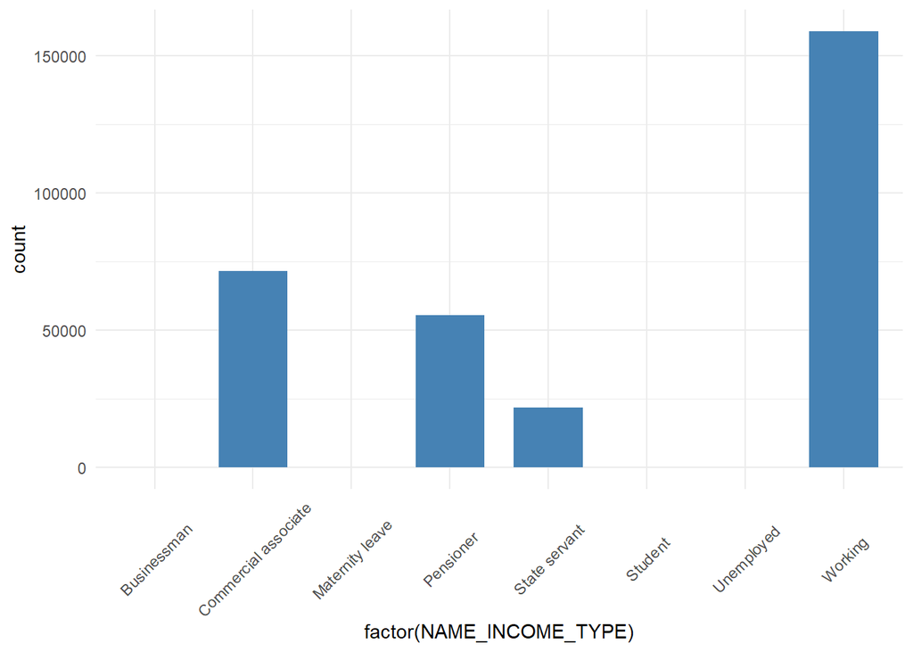

```r
customer_data_income_type <- ggplot(customer_data, aes(x=factor(NAME_INCOME_TYPE))) +
  geom_bar(stat="count", width=0.7, fill="steelblue") +
  theme_minimal() +
  theme(axis.text.x = element_text(angle = 45, vjust = 0.5))
customer_data_income_type
```

## Most credit consumers are working for salary or potentially a business owner as the typical age is working age, with some people being older taking out a loan on a house or other property.

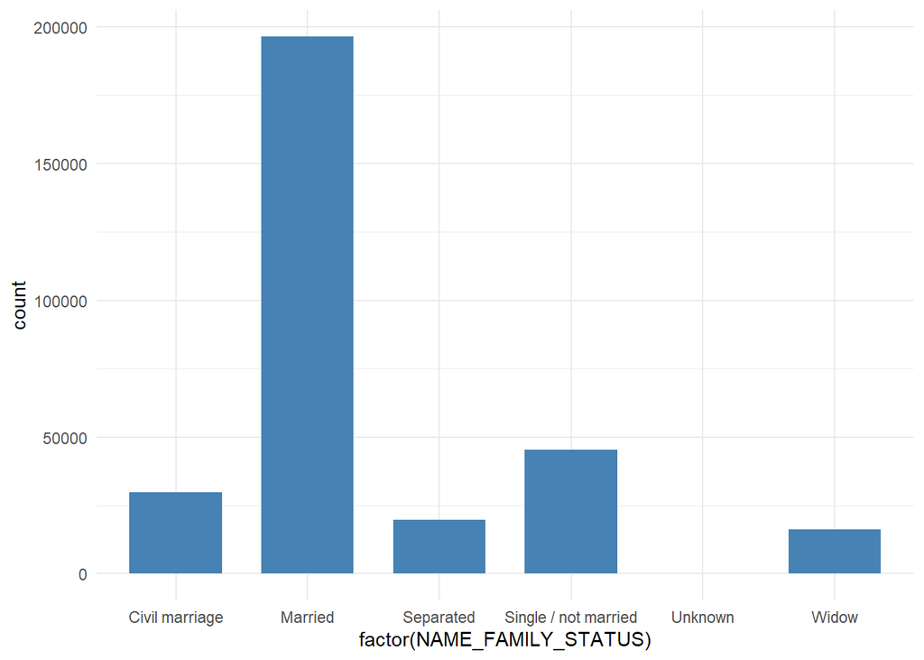

```r
customer_data_family_status <- ggplot(customer_data, aes(x=factor(NAME_FAMILY_STATUS))) +
  geom_bar(stat="count", width=0.7, fill="steelblue") +
  theme_minimal()
customer_data_family_status
```

## Most data in the above graph supports our customers are married, with some being separated or single. Married age people are ones looking for property or looking for a business loan to implement for a business.

```r
tabyl(customer_data, CODE_GENDER, NAME_CONTRACT_TYPE)
```

```
##  CODE_GENDER Cash loans Revolving loans
##            F     182800           19648
##            M      95432            9627
##          XNA          0               4
```

```r
tabyl(customer_data, CODE_GENDER, NAME_FAMILY_STATUS)
```

```
##  CODE_GENDER Civil marriage Married Separated Single / not married Unknown
##            F          20769  122445     15461                28584       1
##            M           9005   73984      4309                16860       1
##          XNA              1       3         0                    0       0
##  Widow
##  15188
##    900
##      0
```

```r
tabyl(customer_data, CODE_GENDER, NAME_EDUCATION_TYPE)
```

```
##  CODE_GENDER Academic degree Higher education Incomplete higher Lower secondary
##            F             100            50289              6283            2311
##            M              64            24573              3993            1505
##          XNA               0                1                 1               0
##  Secondary / secondary special
##                         143465
##                          74924
##                              2
```

```r
tabyl(customer_data, NAME_HOUSING_TYPE, FLAG_OWN_REALTY)
```

```
##    NAME_HOUSING_TYPE     N      Y
##      Co-op apartment   424    698
##    House / apartment 73671 199197
##  Municipal apartment  6822   4361
##     Office apartment  1224   1393
##     Rented apartment  2795   2086
##         With parents  9263   5577
```

```r
tabyl(customer_data, NAME_EDUCATION_TYPE, OCCUPATION_TYPE)
```

```
##            NAME_EDUCATION_TYPE Accountants Cleaning staff Cooking staff
##                Academic degree           8              2             1
##               Higher education        5798            250           427
##              Incomplete higher         445             49           118
##                Lower secondary          18            108            64
##  Secondary / secondary special        3544           4244          5336
##  Core staff Drivers High skill tech staff HR staff IT staff Laborers
##          25       5                     3        0        0        9
##       13313    2050                  4655      357      341     6578
##        1466     491                   585       36       52     1587
##         123     249                    31        0        1      730
##       12643   15808                  6106      170      132    46282
##  Low-skill Laborers Managers Medicine staff Private service staff Realty agents
##                   1       37              0                     2             1
##                  81    11499            999                   519           227
##                  30      931            146                   114            47
##                  92       57             77                    11             2
##                1889     8847           7315                  2006           474
##  Sales staff Secretaries Security staff Waiters/barmen staff emptystring_
##            9           0              4                    0           57
##         5562         481            821                  179        20726
##         1468          96            156                   94         2366
##          228           4             97                   17         1907
##        24835         724           5643                 1058        71335
```

```r
tabyl(customer_data, NAME_INCOME_TYPE, NAME_EDUCATION_TYPE)
```

```
##      NAME_INCOME_TYPE Academic degree Higher education Incomplete higher
##           Businessman               0               10                 0
##  Commercial associate              43            24025              3400
##       Maternity leave               0                3                 0
##             Pensioner              26             8188               518
##         State servant              23             8863               770
##               Student               0                6                 1
##            Unemployed               0                6                 3
##               Working              72            33762              5585
##  Lower secondary Secondary / secondary special
##                0                             0
##              460                         43689
##                0                             2
##             1529                         45101
##              102                         11945
##                0                            11
##                0                            13
##             1725                        117630
```

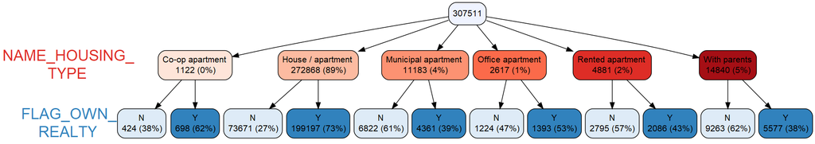

```r
vtree(customer_data, c("NAME_HOUSING_TYPE", "FLAG_OWN_REALTY"),
      fillcolor = c( LanguageGroup = "#e7d4e8", Gender = "#99d8c9"),
      horiz = FALSE)
```

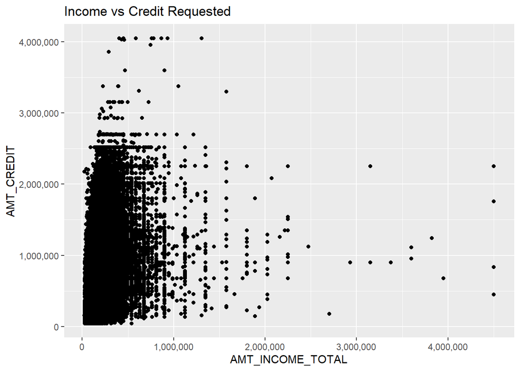

```r
customer_data_income_cleaned <- customer_data %>% filter(AMT_INCOME_TOTAL < 5000000)
income_vs_credit_applied <- ggplot(customer_data_income_cleaned, aes(x=AMT_INCOME_TOTAL, y=AMT_CREDIT)) + geom_point() + scale_y_continuous(label=scales::comma) +
scale_x_continuous(label=scales::comma) +
ggtitle("Income vs Credit Requested")
income_vs_credit_applied
```

## Above shows a cleaned data set and filtered for outliers in order to see patterns in the plot used. While there are a few outliers with high income, these could either be potential mistakes or wealthy individuals. This is purely to make the graph readable to users. There is a loose positive relationship betweeen credit and income levels. Some high income levels proposed to take out middle level of credit, while some lower income individuals have taken a very high level of credit used. Possibly for a business or for real estate.

## Section 2

## Bank Complaint Data and Credit Institutions

```r
bank_complaint_data <- read.csv(file = 'Bank_Complaint_Data.csv')

tabyl(bank_complaint_data, Timely.response., Company.response.to.consumer)
```

```
##  Timely.response. Closed Closed with explanation Closed with monetary relief
##                No     78                   10715                         360
##               Yes    561                  883074                       36800
##  Closed with non-monetary relief Closed with relief Closed without relief
##                              548                  0                     6
##                            98667                 44                   182
##  In progress Untimely response emptystring_
##            0              4143            0
##        13395                 0            2
```

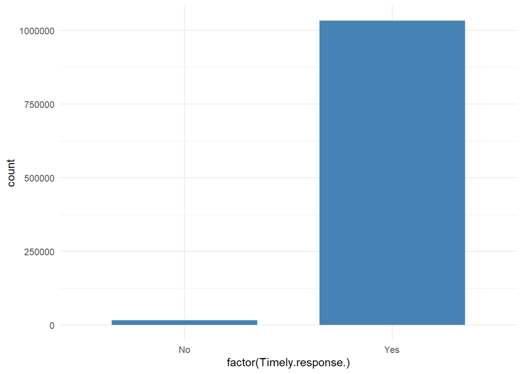

```r
bank_complaint_data_response_time <- ggplot(bank_complaint_data, aes(x=factor(Timely.response.))) +
  geom_bar(stat="count", width=0.7, fill="steelblue") +
  theme(axis.text.x = element_text(angle = 90, vjust = 0.5)) +
  theme_minimal()
bank_complaint_data_response_time
```

## The ggplot for response time supports a graph of timely responses to complaint cases. The chart supports “yes” as the response for an overwhelming number of cases.

```r
bank_complaint_issues <- count(bank_complaint_data, "Issue")
ranked_bank_complaint_issues <- bank_complaint_issues %>% arrange(desc(freq))
head(ranked_bank_complaint_issues, 30)
```

```
##                                                                               Issue
## 1                                              Incorrect information on your report
## 2  Problem with a credit reporting company's investigation into an existing problem
## 3                                                 Attempts to collect debt not owed
## 4                                                       Improper use of your report
## 5                                                               Managing an account
## 6                                                   Written notification about debt
## 7                                                    Trouble during payment process
## 8                                   Problem with a purchase shown on your statement
## 9                                                        Struggling to pay mortgage
## 10                                                            Communication tactics
## 11                                               False statements or representation
## 12                              Took or threatened to take negative or legal action
## 13                                             Dealing with your lender or servicer
## 14                      Applying for a mortgage or refinancing an existing mortgage
```

[output cut: 47 more lines]

```r
bank_complaint_products <- count(bank_complaint_data, "Product")
ranked_bank_complaint_products <- bank_complaint_products %>% arrange(desc(freq))
head(ranked_bank_complaint_products, 30)
```

```
##                                                                         Product
## 1  Credit reporting, credit repair services, or other personal consumer reports
## 2                                                               Debt collection
## 3                                                   Credit card or prepaid card
## 4                                                                      Mortgage
## 5                                                   Checking or savings account
## 6                                                                  Student loan
## 7                            Money transfer, virtual currency, or money service
## 8                                                         Vehicle loan or lease
## 9                                     Payday loan, title loan, or personal loan
## 10                                                             Credit reporting
## 11                                                                  Credit card
## 12                                                      Bank account or service
## 13                                                                Consumer Loan
## 14                                                              Money transfers
```

[output cut: 23 more lines]

## The section above in two parts takes the set of complaint types that customers have filed against the banks and then organizes a list of types of products that have had the most issues and the frequency of such complaints. The top three results with many occurances all relate to credit products and specifically with credit reporting being notable. I assumed mortgage products would be highest but this is not the case. Most issues at the top are either poor investigation quality or incorrect information in reports. Reviewing sub.issue is important to delve into the specifics of what is going on.

```r
bank_complaint_sub_issues <- count(bank_complaint_data, "Sub.issue")
ranked_bank_complaint_sub_issues <- bank_complaint_sub_issues %>% arrange(desc(freq))
head(ranked_bank_complaint_sub_issues, 30)
```

```
##                                                                                Sub.issue
## 1                                                    Information belongs to someone else
## 2
## 3                                Their investigation did not fix an error on your report
## 4                                                               Account status incorrect
## 5                                                          Account information incorrect
## 6                                                                      Debt is not yours
## 7                               Credit inquiries on your report that you don't recognize
## 8                                                   Investigation took more than 30 days
## 9                                       Didn't receive enough information to verify debt
## 10                                   Was not notified of investigation status or results
## 11                                                     Debt was result of identity theft
## 12                                                        Personal information incorrect
## 13                                         Reporting company used your report improperly
## 14                                                              Deposits and withdrawals
```

[output cut: 47 more lines]

## The subissues here corroborate the data in the prior section as information is either incorrect or status is incorrect. This supports more reports are filed for data on the consumer rather than a product in its self. This is against my initial hypothesis that poor products or dishonest selling of goods was responsible. Now we can look at the banks/institutions of interest for these complaints.

```r
bank_complaint_companies <- count(bank_complaint_data, "Company")
ranked_bank_complaint_companies <- bank_complaint_companies %>% arrange(desc(freq))
head(ranked_bank_complaint_companies, 30)
```

```
##                                   Company   freq
## 1                           EQUIFAX, INC. 173495
## 2  TRANSUNION INTERMEDIATE HOLDINGS, INC. 170325
## 3     Experian Information Solutions Inc. 154586
## 4   BANK OF AMERICA, NATIONAL ASSOCIATION  27809
## 5                    JPMORGAN CHASE & CO.  27699
## 6       CAPITAL ONE FINANCIAL CORPORATION  26011
## 7                   WELLS FARGO & COMPANY  24602
## 8                          CITIBANK, N.A.  23886
## 9                     SYNCHRONY FINANCIAL  14247
## 10                Navient Solutions, LLC.  11744
## 11                           U.S. BANCORP   9879
## 12               AMERICAN EXPRESS COMPANY   8697
## 13            Alliance Data Card Services   8458
## 14      PORTFOLIO RECOVERY ASSOCIATES INC   8445
```

[output cut: 16 more lines]

## As expected from the other data, the firms most responsble for issues were the three credit monitoring bureaus by a wide margin versus every other institution. This is the result of one of two things, there are a significant issue of the credit monitoring bureaus providing good service, and/or these products and services generate a high amount of compalints against other goods. So a mortgage has rarely an issue if conducted properly in documentation, while credit that is incorrectly reported will get the attention of customers. Credit is important to access credit goods, so customers watch these indicators very closely. Now lets use choropleth data to map how complaints occur across the U.S.

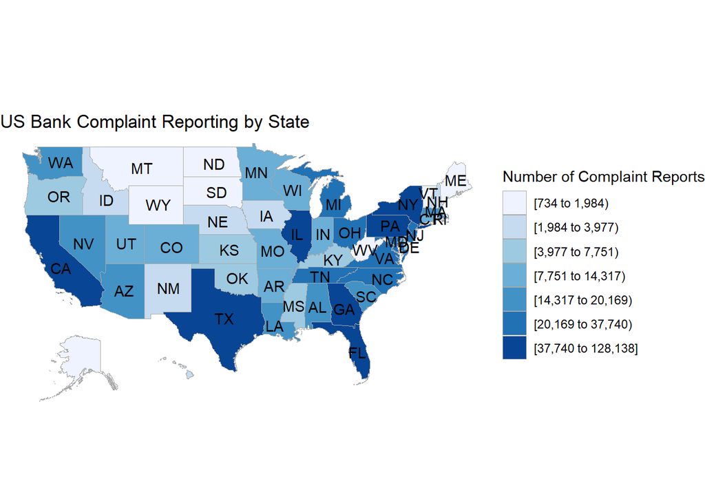

```r
data(state.regions)
bank_complaint_choropleth_data <- bank_complaint_data %>% group_by(State) %>% summarize(Frequency = count(State))
bank_complaint_choropleth_data <- bank_complaint_choropleth_data[-c(1,2,3,6,8,16,18,30,34,49,55,58), ]
bank_complaint_choropleth_data <- cbind(bank_complaint_choropleth_data, state.regions)

bank_complaint_choropleth_final <- subset(bank_complaint_choropleth_data, select = -c(1,4,5,6))
colnames(bank_complaint_choropleth_final) <- c("value", "region")

bank_complaint_choropleth_plot <- state_choropleth(bank_complaint_choropleth_final, title  = "US Bank Complaint Reporting by State", legend = "Number of Complaint Reports")
bank_complaint_choropleth_plot
```

## The data in the choropleth map support where the highest number of complaints occur without respect to population per capita. The data shows that the northeast and California have highest number of complaints filed while there is a notable amount of complaints filed in Georgia, Illinois, Florida, and Texas. These areas have a marginally high income but also have a high number of urban centers or older populations that can be seen as vulnerable.

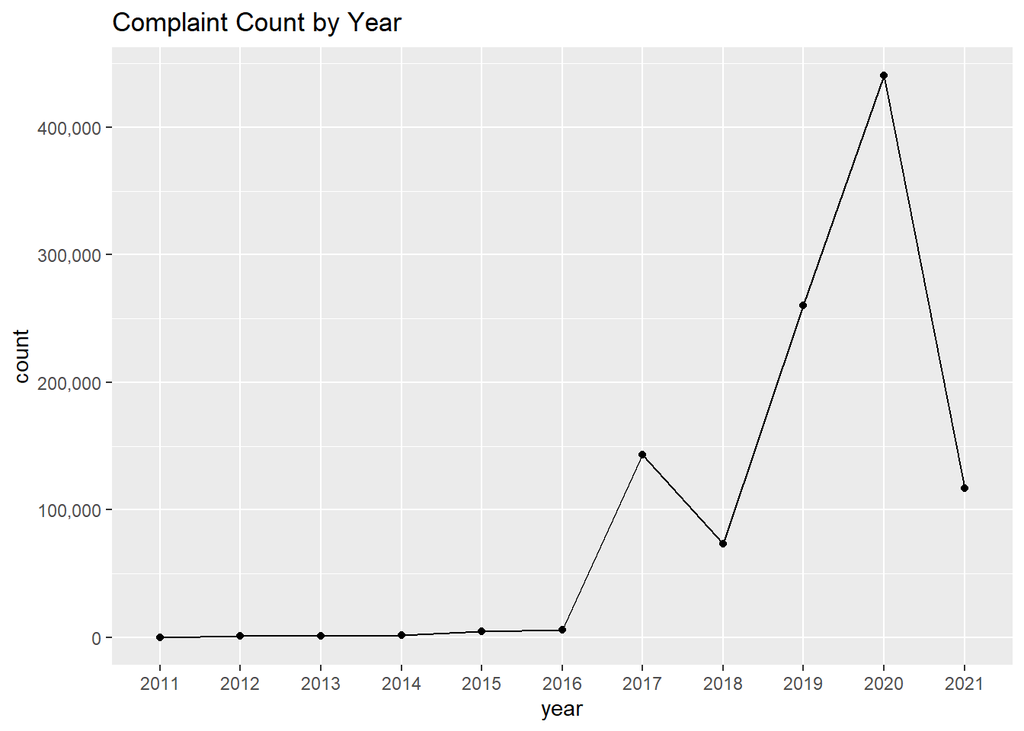

```r
complaints_over_time <- bank_complaint_data %>% select(1,18)
complaints_over_time$year_month_day <-mdy(complaints_over_time$Date.received)
complaints_over_time$year_month <- format(complaints_over_time$year_month_day, "%Y-%m")
complaints_over_time$year <- format(complaints_over_time$year_month_day, "%Y")

complaints_time_series_y_m <- complaints_over_time %>%
  group_by(year_month) %>%
  dplyr::summarize(count = n())

complaints_time_series_y <- complaints_over_time %>%
  group_by(year) %>%
  dplyr::summarize(count = n())

complaints_time_series_year_plot <- ggplot(data = complaints_time_series_y, aes(year,count, group=1)) +
  geom_line() +
  geom_point() +
  scale_y_continuous(label=scales::comma) +
  ggtitle("Complaint Count by Year")
complaints_time_series_year_plot
```

## The charting above is the year by year output of complaints since the reporting began in 2011. There is a notable spike from 2017 to 2020 in the number of complaints filed. Chances are that this spike is due to the increasing reporting requirements from lenders and higher awareness of consumers to file a complaint, rather a dramatic increase in bad reporting or fradulent activity. 2021 is only lower due to the fact that we are only 4 months into the year so its not a fair comparison.

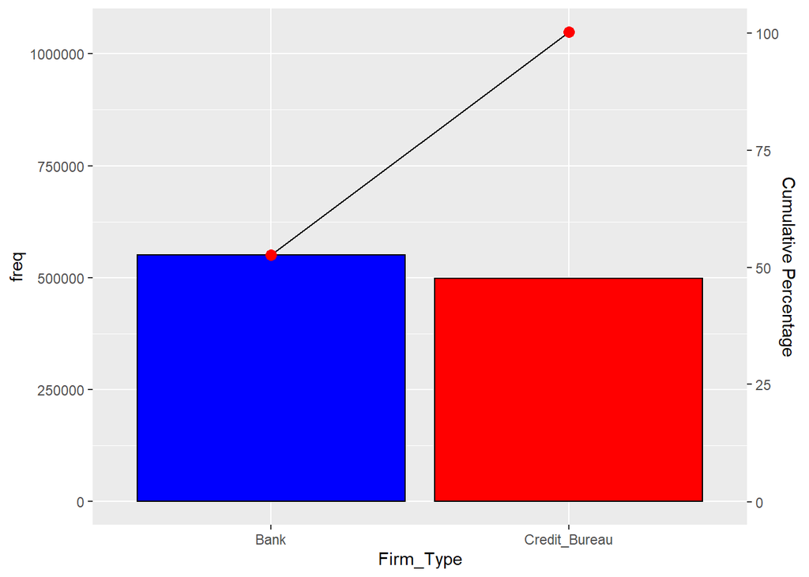

```r
bank_complaint_firms <- bank_complaint_data %>% select(8,18)

bank_complaint_firms$Firm_Type <- NA


bank_complaint_firms$Firm_Type[bank_complaint_firms$Company == "EQUIFAX, INC."] <- "Credit_Bureau"
bank_complaint_firms$Firm_Type[bank_complaint_firms$Company == "TRANSUNION INTERMEDIATE HOLDINGS, INC."] <- "Credit_Bureau"
bank_complaint_firms$Firm_Type[bank_complaint_firms$Company == "Experian Information Solutions Inc."] <- "Credit_Bureau"

bank_complaint_firms[,c("Firm_Type")][is.na(bank_complaint_firms[,c("Firm_Type")])] <- "Bank"
View(bank_complaint_firms)

bank_complaint_firms_counts <- count(bank_complaint_firms, "Firm_Type")

bank_complaint_firms_pareto <- ggplot(bank_complaint_firms_counts, aes(x=Firm_Type, y=freq)) +
 stat_pareto(point.color = "red",
             point.size = 3,
             line.color = "black",
             #size.line = 1,
             bars.fill = c("blue", "red"),
 )
bank_complaint_firms_pareto
```

```r
firm_frequencies <- freq(bank_complaint_firms$Firm_Type)
firm_frequencies
```

```
##
##
## **Frequency table**
##
## Class:      character
## Length:     1,048,575
## Available:  1,048,575 (100%, NA: 0 = 0%)
## Unique:     2
##
## Shortest:   4
## Longest:    13
##
##
## |   |Item          |  Count| Percent| Cum. Count| Cum. Percent|
## |:--|:-------------|------:|-------:|----------:|------------:|
## |1  |Bank          | 550169|  52.47%|     550169|       52.47%|
## |2  |Credit_Bureau | 498406|  47.53%|    1048575|      100.00%|
```

## The last graph of this section supports a Pareto analysis of the proportion of complaints that occur for banking institutions against credit bureaus. As a whole we see three firms, the credit bureaus, against all other firms. This is signficant because the banks have thousands of companies listed and have only about half the count of complaints. The credit bureaus have a disproportionate amount of issues relative to all other institutions. A pareto analysis is a good graphic measure of this information.